# Analisis de vinos

2024-07-14

```r
library(readr)

calidad_vinos <- read_delim("calidad_vinos.csv", delim = ";", escape_double = FALSE, trim_ws = TRUE)
calidad_vinos
```

```
## # A tibble: 6,497 × 13
##    `acidez fija` `acidez volátil` `ácido cítrico` `azúcar residual` cloruros
##            <dbl>            <dbl>           <dbl>             <dbl>    <dbl>
##  1           7               0.27            0.36              20.7    0.045
##  2           6.3             0.3             0.34               1.6    0.049
##  3           8.1             0.28            0.4                6.9    0.05
##  4           7.2             0.23            0.32               8.5    0.058
##  5           7.2             0.23            0.32               8.5    0.058
##  6           8.1             0.28            0.4                6.9    0.05
##  7           6.2             0.32            0.16               7      0.045
##  8           7               0.27            0.36              20.7    0.045
##  9           6.3             0.3             0.34               1.6    0.049
## 10           8.1             0.22            0.43               1.5    0.044
## # ℹ 6,487 more rows
## # ℹ 8 more variables: `anhídrido sulfuroso libre` <dbl>,
## #   `anhídrido sulfuroso total` <dbl>, densidad <dbl>, pH <dbl>,
## #   sulfatos <dbl>, alcohol <dbl>, calidad <dbl>, variedad <chr>
```

```r
View(calidad_vinos)
```

## Muestreo Estartificado

```r
library(dplyr)
set.seed(531)
muestra_vinos <- calidad_vinos%>%
  group_by(variedad)%>%
   sample_frac(size = 2000 / nrow(calidad_vinos))

muestra_vinos
```

```
## # A tibble: 2,000 × 13
## # Groups:   variedad [2]
##    `acidez fija` `acidez volátil` `ácido cítrico` `azúcar residual` cloruros
##            <dbl>            <dbl>           <dbl>             <dbl>    <dbl>
##  1           7              0.27             0.36              20.7    0.045
##  2           6.6            0.22             0.3               14.7    0.045
##  3           7.8            0.19             0.32               7.4    0.015
##  4           6.9            0.19             0.32               7.9    0.042
##  5           4.7            0.335            0.14               1.3    0.036
##  6           6.9            0.19             0.49               6.6    0.036
##  7           6.1            0.37             0.46              12      0.042
##  8           8              0.17             0.29               2.4    0.029
##  9           6              0.29             0.27               2.3    0.044
## 10           6.9            0.2              0.4                7.7    0.032
## # ℹ 1,990 more rows
## # ℹ 8 more variables: `anhídrido sulfuroso libre` <dbl>,
## #   `anhídrido sulfuroso total` <dbl>, densidad <dbl>, pH <dbl>,
## #   sulfatos <dbl>, alcohol <dbl>, calidad <dbl>, variedad <chr>
```

```r
total_observations <- nrow(muestra_vinos)
print(total_observations)
```

```
## [1] 2000
```

## Test de Hipotesis

```r
library(dplyr)
library(tidyverse)
library(BSDA)
library(car)
library(datarium)
library(reshape2)
library(openintro)
library(RVAideMemoire)
library(dplyr)
library(car)
library(stats)


View(muestra_vinos)
unique(muestra_vinos$variedad)
```

```
## [1] "blanco" "tinto"
```

```r
colnames(muestra_vinos)
```

```
##  [1] "acidez fija"               "acidez volátil"
##  [3] "ácido cítrico"             "azúcar residual"
##  [5] "cloruros"                  "anhídrido sulfuroso libre"
##  [7] "anhídrido sulfuroso total" "densidad"
##  [9] "pH"                        "sulfatos"
## [11] "alcohol"                   "calidad"
## [13] "variedad"
```

```r
muestra_vinos_blanco <- muestra_vinos %>%
  filter(variedad == 'blanco') %>%
  pull(`densidad`)

muestra_vinos_tinto <- muestra_vinos %>%
  filter(variedad == 'tinto') %>%
  pull(`densidad`)

head(muestra_vinos_blanco)
```

```
## [1] 1.00100 0.99704 0.99278 0.99456 0.99212 0.99320
```

```r
head(muestra_vinos_tinto)
```

```
## [1] 0.99650 0.99820 0.99760 0.99700 0.99760 0.99064
```

```r
shapiro.test(muestra_vinos_blanco)
```

```
##
##  Shapiro-Wilk normality test
##
## data:  muestra_vinos_blanco
## W = 0.97936, p-value = 6.711e-14
```

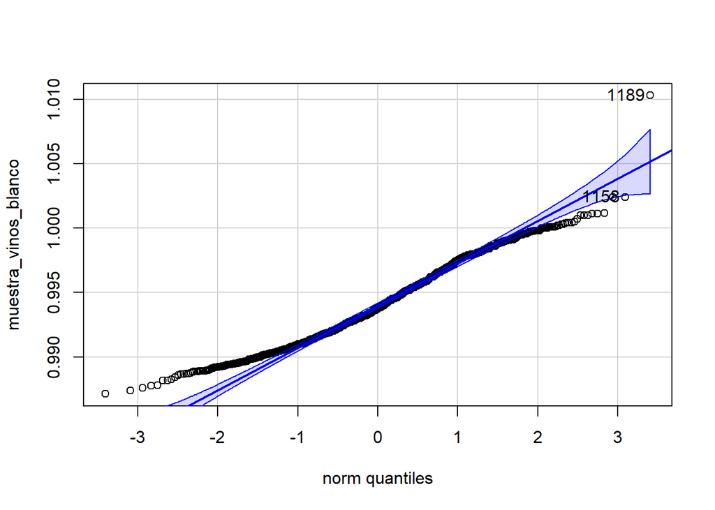

```
## [1] 1189 1158
```

```r
qqPlot(muestra_vinos_blanco)
```

```r
shapiro.test(muestra_vinos_tinto)
```

```
##
##  Shapiro-Wilk normality test
##
## data:  muestra_vinos_tinto
## W = 0.99399, p-value = 0.04888
```

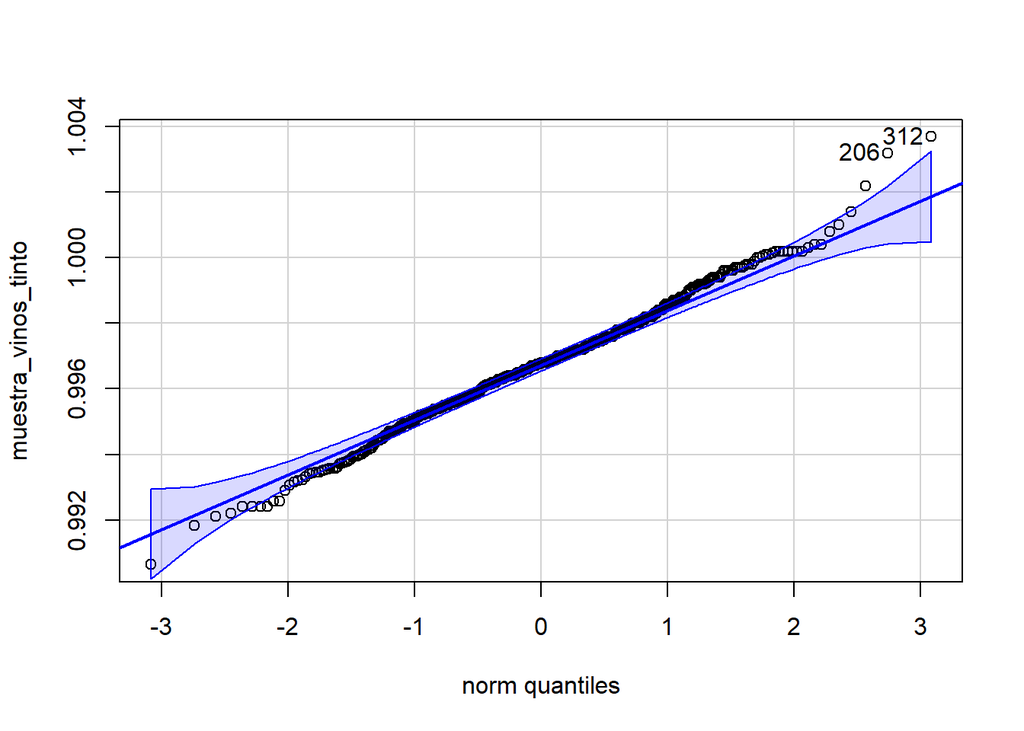

```
## [1] 312 206
```

```r
qqPlot(muestra_vinos_tinto)
```

levene_test <- leveneTest(`densidad` ~ `variedad`, data = muestra_vinos)

levene_test

resultado_ttest <- t.test(muestra_vinos_tinto, muestra_vinos_blanco, var.equal = TRUE, alternative = “two.sided”)

resultado_ttest

resultado_wilcox <- wilcox.test(muestra_vinos_tinto, muestra_vinos_blanco)

resultado_wilcox

[output not shown]

## Analisis de regresion multiple

```r
muestra_vinos
```

```
## # A tibble: 2,000 × 13
## # Groups:   variedad [2]
##    `acidez fija` `acidez volátil` `ácido cítrico` `azúcar residual` cloruros
##            <dbl>            <dbl>           <dbl>             <dbl>    <dbl>
##  1           7              0.27             0.36              20.7    0.045
##  2           6.6            0.22             0.3               14.7    0.045
##  3           7.8            0.19             0.32               7.4    0.015
##  4           6.9            0.19             0.32               7.9    0.042
##  5           4.7            0.335            0.14               1.3    0.036
##  6           6.9            0.19             0.49               6.6    0.036
##  7           6.1            0.37             0.46              12      0.042
##  8           8              0.17             0.29               2.4    0.029
##  9           6              0.29             0.27               2.3    0.044
## 10           6.9            0.2              0.4                7.7    0.032
## # ℹ 1,990 more rows
## # ℹ 8 more variables: `anhídrido sulfuroso libre` <dbl>,
## #   `anhídrido sulfuroso total` <dbl>, densidad <dbl>, pH <dbl>,
## #   sulfatos <dbl>, alcohol <dbl>, calidad <dbl>, variedad <chr>
```

```r
library(corrplot)
library(tidymodels)
library(dplyr)
library(tidyverse)
library(BSDA)
library(car)
library(datarium)
library(reshape2)
library(openintro)
library(RVAideMemoire)
library(dplyr)
library(car)
library(stats)
library(class)
library(rsample)

muestra_vinos_numericas <- muestra_vinos %>%
  select_if(is.numeric)

muestra_vinos_numericas <- muestra_vinos_numericas[, !names(muestra_vinos_numericas) %in% "variedad"]
correlaciones <- cor(muestra_vinos_numericas)
correlaciones
```

```
##                           acidez fija acidez volátil ácido cítrico
## acidez fija                1.00000000     0.18834687   0.339874698
## acidez volátil             0.18834687     1.00000000  -0.398739960
## ácido cítrico              0.33987470    -0.39873996   1.000000000
## azúcar residual           -0.10389808    -0.21142302   0.151036503
## cloruros                   0.31690609     0.37960656  -0.002113573
## anhídrido sulfuroso libre -0.26724422    -0.35086553   0.162741040
## anhídrido sulfuroso total -0.32284531    -0.41627518   0.212162476
## densidad                   0.47420197     0.24282084   0.090974337
## pH                        -0.25124893     0.27529949  -0.346597049
## sulfatos                   0.32586260     0.19672069   0.068879395
## alcohol                   -0.10463841    -0.03842267   0.015507692
## calidad                   -0.04696177    -0.29554048   0.150151365
##                           azúcar residual     cloruros
## acidez fija                    -0.1038981  0.316906094
## acidez volátil                 -0.2114230  0.379606557
## ácido cítrico                   0.1510365 -0.002113573
## azúcar residual                 1.0000000 -0.130226949
## cloruros                       -0.1302269  1.000000000
## anhídrido sulfuroso libre       0.4115158 -0.188944677
## anhídrido sulfuroso total       0.5145148 -0.266541078
## densidad                        0.5475384  0.373187994
## pH                             -0.2835104  0.034953932
## sulfatos                       -0.1776438  0.377246783
## alcohol                        -0.3748550 -0.256261360
## calidad                        -0.0510042 -0.193805775
##                           anhídrido sulfuroso libre anhídrido sulfuroso total
## acidez fija                             -0.26724422               -0.32284531
## acidez volátil                          -0.35086553               -0.41627518
## ácido cítrico                            0.16274104                0.21216248
## azúcar residual                          0.41151579                0.51451480
## cloruros                                -0.18894468               -0.26654108
## anhídrido sulfuroso libre                1.00000000                0.71253167
## anhídrido sulfuroso total                0.71253167                1.00000000
## densidad                                 0.03780406                0.04346830
## pH                                      -0.16468505               -0.24442191
## sulfatos                                -0.15595964               -0.23814559
## alcohol                                 -0.16528916               -0.24937570
## calidad                                  0.03928571               -0.04973484
##                               densidad           pH    sulfatos     alcohol
```

[output cut: 10 more lines]

```
## alcohol                   -0.704032973  0.132465725 -0.02224528  1.00000000
## calidad                   -0.300868561 -0.016757675  0.04435970  0.43305396
##                               calidad
## acidez fija               -0.04696177
## acidez volátil            -0.29554048
## ácido cítrico              0.15015137
## azúcar residual           -0.05100420
## cloruros                  -0.19380577
## anhídrido sulfuroso libre  0.03928571
## anhídrido sulfuroso total -0.04973484
## densidad                  -0.30086856
## pH                        -0.01675768
## sulfatos                   0.04435970
## alcohol                    0.43305396
## calidad                    1.00000000
```

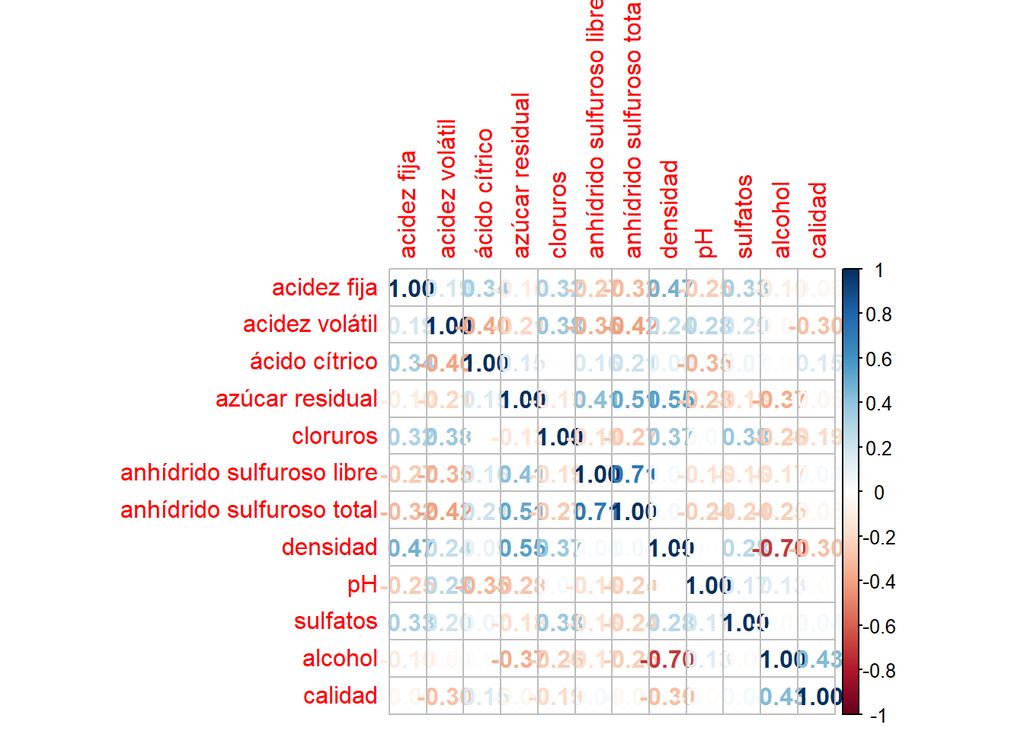

```r
corrplot(correlaciones, method = "number")
```

```r
colnames(muestra_vinos)
```

```
##  [1] "acidez fija"               "acidez volátil"
##  [3] "ácido cítrico"             "azúcar residual"
##  [5] "cloruros"                  "anhídrido sulfuroso libre"
##  [7] "anhídrido sulfuroso total" "densidad"
##  [9] "pH"                        "sulfatos"
## [11] "alcohol"                   "calidad"
## [13] "variedad"
```

```r
library(ggplot2)
library(car)
library(dplyr)
library(rsample)

# Establecer la semilla para la reproducibilidad
set.seed(531)

# Seleccionar las columnas relevantes
df_vinos <- muestra_vinos %>%
  select(alcohol, densidad, `azúcar residual`)
# Dividir el data frame en conjunto de entrenamiento y prueba
df_split_vinos <- initial_split(df_vinos, prop = 0.8)

df_train_vinos <- training(df_split_vinos)
df_test_vinos <- testing(df_split_vinos)

# Imprimir el tamaño del conjunto de entrenamiento
paste0("Total del dataset de entrenamiento: ", nrow(df_train_vinos))
```

```
## [1] "Total del dataset de entrenamiento: 1600"
```

```r
# Ajustar el modelo de regresión múltiple
modelo <- lm(alcohol ~ densidad + `azúcar residual`, data = df_train_vinos)


# Resumen del modelo
summary(modelo)
```

```
##
## Call:
## lm(formula = alcohol ~ densidad + `azúcar residual`, data = df_train_vinos)
##
## Residuals:
##     Min      1Q  Median      3Q     Max
## -2.2305 -0.6027 -0.0756  0.5544  3.5289
##
## Coefficients:
##                     Estimate Std. Error t value Pr(>|t|)
## (Intercept)        3.013e+02  8.680e+00  34.717   <2e-16 ***
## densidad          -2.924e+02  8.743e+00 -33.446   <2e-16 ***
## `azúcar residual`  6.039e-03  5.435e-03   1.111    0.267
## ---
## Signif. codes:  0 '***' 0.001 '**' 0.01 '*' 0.05 '.' 0.1 ' ' 1
##
## Residual standard error: 0.8513 on 1597 degrees of freedom
## Multiple R-squared:  0.4998, Adjusted R-squared:  0.4992
## F-statistic: 797.8 on 2 and 1597 DF,  p-value: < 2.2e-16
```

```r
# Calcular residuos y predicciones
residuos <- resid(modelo)
residuos_estandarizados <- rstandard(modelo)
predichos <- predict(modelo)

# Combinar los resultados en un solo data frame
resultados <- cbind(df_train_vinos, predichos = predichos, residuos = residuos, residuos_estandarizados = round(residuos_estandarizados, 2))

shapiro.test(resid(modelo))
```

```
##
##  Shapiro-Wilk normality test
##
## data:  resid(modelo)
## W = 0.98781, p-value = 2.394e-10
```

```r
# Ver los primeros registros del data frame combinado
head(resultados)
```

```
## # A tibble: 6 × 7
## # Groups:   variedad [2]
##   variedad alcohol densidad `azúcar residual` predichos residuos
##   <chr>      <dbl>    <dbl>             <dbl>     <dbl>    <dbl>
## 1 blanco      12.9    0.989               2.4     12.0     0.892
## 2 blanco       9.4    0.998              12.5      9.65   -0.254
## 3 tinto       10      0.998               1.6      9.41    0.588
## 4 blanco       9      0.995               5.4     10.4    -1.43
## 5 blanco      12.2    0.992               1.5     11.3     0.887
## 6 blanco      10.4    0.999              16.3      9.41    0.987
## # ℹ 1 more variable: residuos_estandarizados <dbl>
```

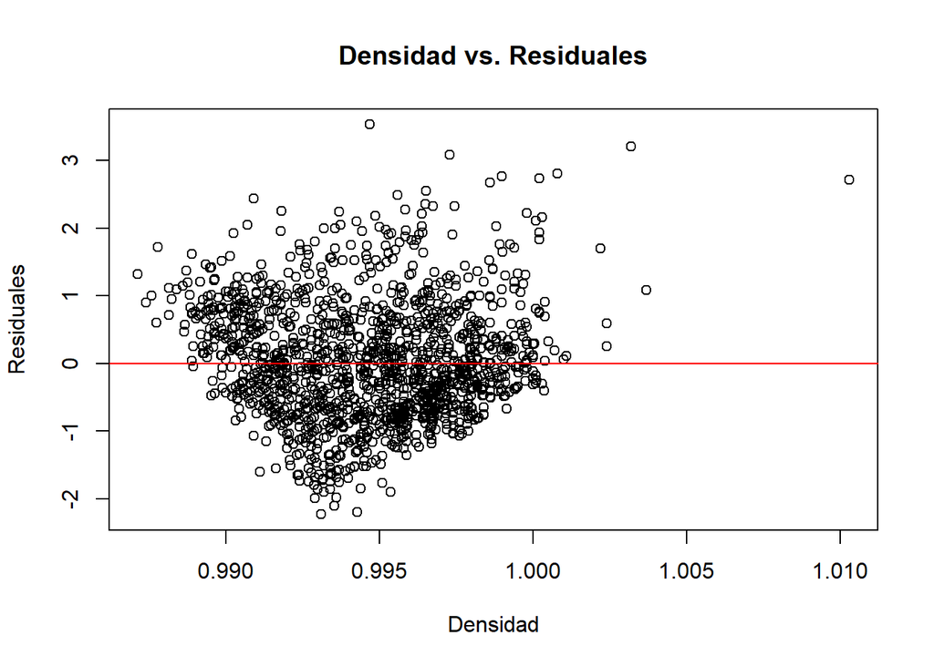

```r
# Evaluar los supuestos del modelo
# 1. LINEARIDAD
plot(df_train_vinos$densidad, residuos, main = "Densidad vs. Residuales", xlab = "Densidad", ylab = "Residuales")
abline(h = 0, col = "red")
```

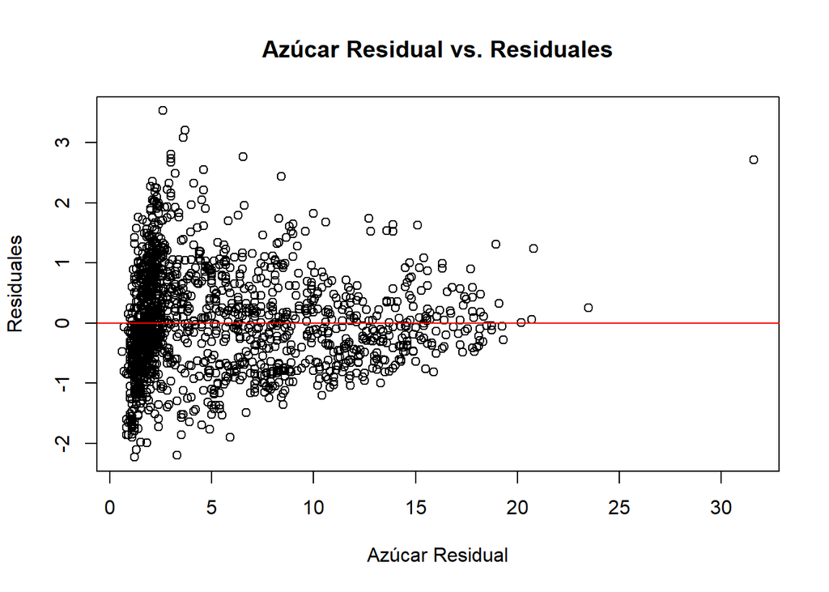

```r
plot(df_train_vinos$`azúcar residual`, residuos, main = "Azúcar Residual vs. Residuales", xlab = "Azúcar Residual", ylab = "Residuales")
abline(h = 0, col = "red")
```

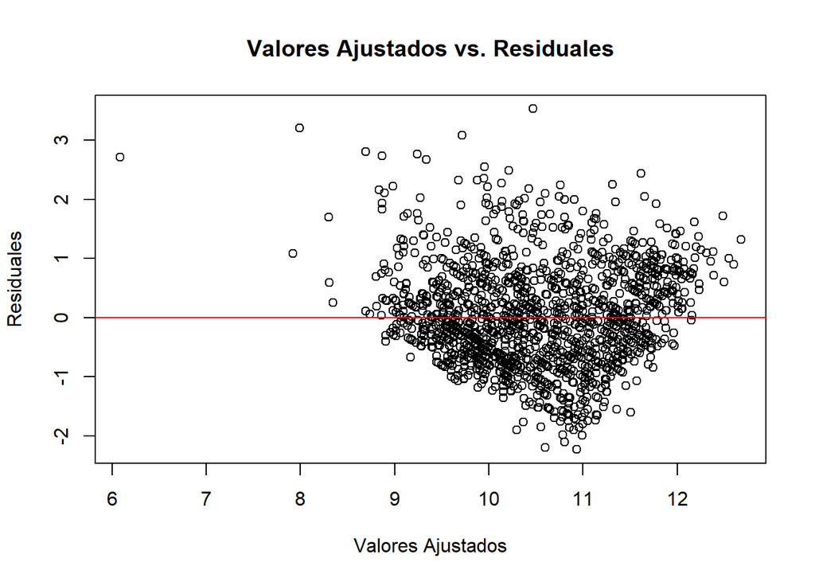

```r
# 2. Homoscedasticity
plot(predichos, residuos, main = "Valores Ajustados vs. Residuales", xlab = "Valores Ajustados", ylab = "Residuales")
abline(h = 0, col = "red")
```

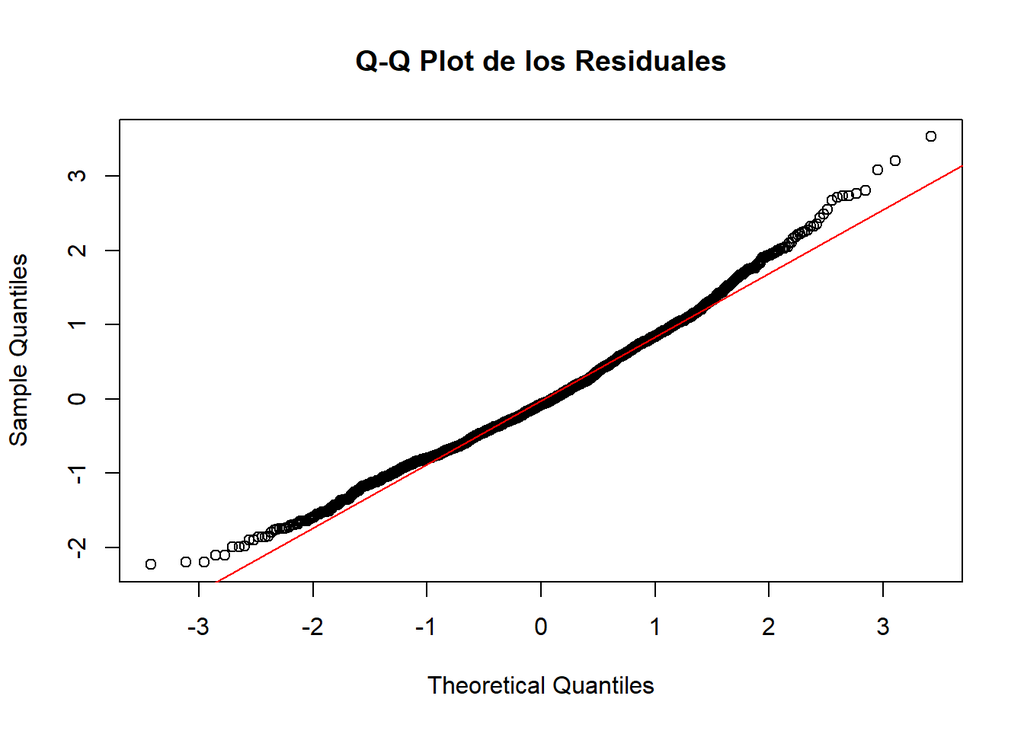

```r
# 3. Normality of residuals
qqnorm(residuos, main = "Q-Q Plot de los Residuales")
qqline(residuos, col = "red")
```

```r
# 4. Multicollinearity
vif(modelo)  # Verificar el Factor de Inflación de la Varianza
```

```
##          densidad `azúcar residual`
##          1.480798          1.480798
```

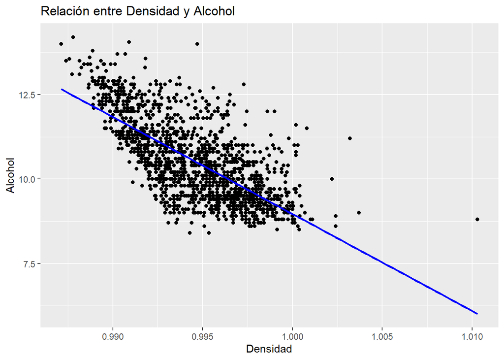

```r
# Visualize the relationship between predictors and the dependent variable
ggplot(data = df_train_vinos, aes(x = densidad, y = alcohol)) +
  geom_point() +
  geom_smooth(method = "lm", col = "blue", se = FALSE) +
  labs(title = "Relación entre Densidad y Alcohol", x = "Densidad", y = "Alcohol")
```

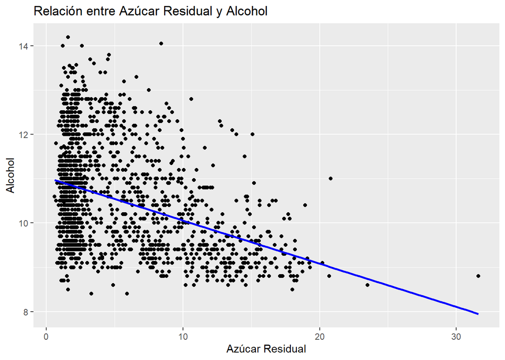

```r
ggplot(data = df_train_vinos, aes(x = `azúcar residual`, y = alcohol)) +
  geom_point() +
  geom_smooth(method = "lm", col = "blue", se = FALSE) +
  labs(title = "Relación entre Azúcar Residual y Alcohol", x = "Azúcar Residual", y = "Alcohol")
```

```r
# Evaluate the model on the test set
predicciones_test <- predict(modelo, df_test_vinos)

# Calculate the Mean Absolute Error (MAE)
mae <- mean(abs(predicciones_test - df_test_vinos$alcohol))
paste0("Error absoluto medio (MAE): ", round(mae, 3))
```

```
## [1] "Error absoluto medio (MAE): 0.629"
```

[output not shown]

# Analisis discriminante: variedad

```r
library(MASS)
library(car)
library(rattle)
library(GGally)
library(mvnormtest)
library(MVN)
library(tidyverse)
library(tidymodels)
library(factoextra)
library(mvShapiroTest)
library(biotools)
library(MASS)
library(klaR)
library(discrim)
```

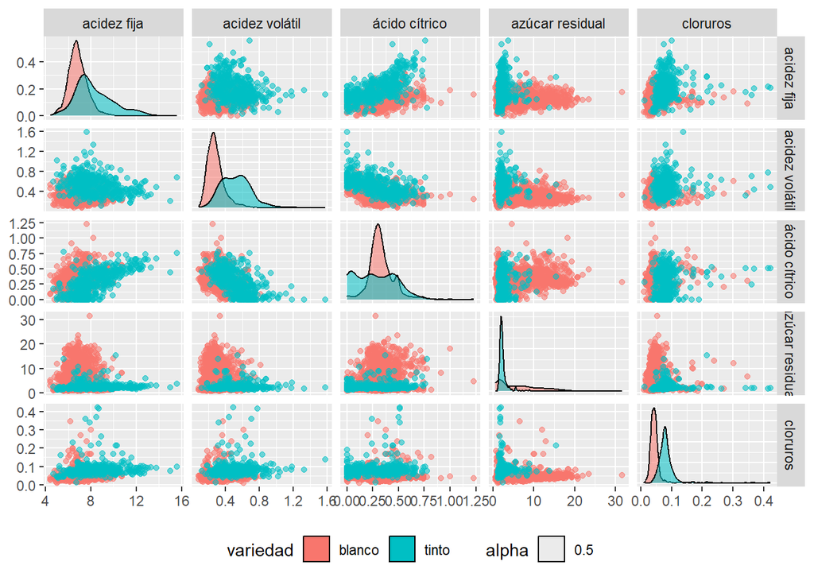

```r
library(dplyr)
library(biotools)

ggpairs(muestra_vinos,
        legend = 1,
        columns = 1:5,
        aes(color = variedad, alpha = 0.5),
        upper = list(continuous = "points"))+
  theme(legend.position = "bottom")
```

```r
muestra_vinosf <- muestra_vinos[, !names(muestra_vinos) %in% "calidad"]

set.seed(531)

df_split <- initial_split(muestra_vinosf,
                          prop = 0.80,
                          strata = variedad)

df_train <- df_split |>
              training() |>
              mutate(across(where(is.numeric), scale))

df_test <- df_split |>
              testing()|>
              mutate(across(where(is.numeric), scale))

blanco<- subset(df_train[,2:5], df_train$variedad == "blanco")
tinto<- subset(df_train[,2:5], df_train$variedad == "tinto")

mvShapiro.Test(as.matrix(blanco))
```

```
##
##  Generalized Shapiro-Wilk test for Multivariate Normality by
##  Villasenor-Alva and Gonzalez-Estrada
##
## data:  as.matrix(blanco)
## MVW = 0.82593, p-value < 2.2e-16
```

```r
mvShapiro.Test(as.matrix(tinto))
```

```
##
##  Generalized Shapiro-Wilk test for Multivariate Normality by
##  Villasenor-Alva and Gonzalez-Estrada
##
## data:  as.matrix(tinto)
## MVW = 0.75251, p-value < 2.2e-16
```

```r
View(df_train)

df_train$variedad <- as.factor(df_train$variedad)

df_numeric <- df_train[, !names(df_train) %in% "variedad"]

result <- boxM(df_numeric, df_train$variedad)

print(result)
```

```
##
##  Box's M-test for Homogeneity of Covariance Matrices
##
## data:  df_numeric
## Chi-Sq (approx.) = 2382.3, df = 66, p-value < 2.2e-16
```

```r
# Número de datos en test y train
paste0("Total del dataset de entrenamiento: ", nrow(df_train))
```

```
## [1] "Total del dataset de entrenamiento: 1599"
```

```r
wine.lda <- lda(variedad ~ ., data=df_train)

print(wine.lda)
```

```
## Call:
## lda(variedad ~ ., data = df_train)
##
## Prior probabilities of groups:
##    blanco     tinto
## 0.7542214 0.2457786
##
## Group means:
##        `acidez fija` `acidez volátil` `ácido cítrico` `azúcar residual`
## blanco -3.720103e-16     1.679523e-16    1.220243e-16     -2.458172e-17
## tinto  -3.388202e-16    -1.200212e-16   -1.385061e-16      2.227056e-17
##            cloruros `anhídrido sulfuroso libre` `anhídrido sulfuroso total`
## blanco 1.346725e-16                1.106209e-17                1.540792e-16
## tinto  1.068098e-16               -3.067768e-19                2.487016e-17
##            densidad            pH      sulfatos       alcohol
## blanco 1.543324e-14 -1.274151e-15 -1.965321e-16 -1.268817e-16
## tinto  1.996602e-14  6.139417e-16  4.065227e-17 -1.774573e-16
##
## Coefficients of linear discriminants:
##                                     LD1
## `acidez fija`               -0.82450563
## `acidez volátil`            -0.06634990
## `ácido cítrico`             -0.10637264
## `azúcar residual`           -1.46126711
## cloruros                    -0.05313410
## `anhídrido sulfuroso libre`  0.04192254
## `anhídrido sulfuroso total` -0.04833316
## densidad                     2.83805118
## pH                          -0.27838358
## sulfatos                    -0.22035812
## alcohol                      1.46853932
```

```r
predictions <- wine.lda |>
                predict(df_test)
predictions
```

[output not shown]

[output cut: 836 more lines]

```r
predictions2 <- wine.lda |>
                predict(df_train)
predictions2
```

[output not shown]

[output cut: 3351 more lines]

```r
true_classes <- df_test$variedad

true_classes_train <- df_train$variedad

confusion_matrix <- table(Predicted = predictions$class, Actual = true_classes)
print(confusion_matrix)
```

```
##          Actual
## Predicted blanco tinto
##    blanco    302    99
##    tinto       0     0
```

```r
confusion_matrix2 <- table(Predicted = predictions2$class, Actual = true_classes_train)
print(confusion_matrix2)
```

```
##          Actual
## Predicted blanco tinto
##    blanco   1206   393
##    tinto       0     0
```

```r
table(df_train$variedad)
```

```
##
## blanco  tinto
##   1206    393
```

```r
table(df_test$variedad)
```

```
##
## blanco  tinto
##    302     99
```

```r
"Análisis discriminante cuadrático (QDA)"
```

```
## [1] "Análisis discriminante cuadrático (QDA)"
```

```r
model_qda <- qda(variedad ~ ., df_train)
model_qda
```

```
## Call:
## qda(variedad ~ ., data = df_train)
##
## Prior probabilities of groups:
##    blanco     tinto
## 0.7542214 0.2457786
##
## Group means:
##        `acidez fija` `acidez volátil` `ácido cítrico` `azúcar residual`
## blanco -3.720103e-16     1.679523e-16    1.220243e-16     -2.458172e-17
## tinto  -3.388202e-16    -1.200212e-16   -1.385061e-16      2.227056e-17
##            cloruros `anhídrido sulfuroso libre` `anhídrido sulfuroso total`
## blanco 1.346725e-16                1.106209e-17                1.540792e-16
## tinto  1.068098e-16               -3.067768e-19                2.487016e-17
##            densidad            pH      sulfatos       alcohol
## blanco 1.543324e-14 -1.274151e-15 -1.965321e-16 -1.268817e-16
## tinto  1.996602e-14  6.139417e-16  4.065227e-17 -1.774573e-16
```

```r
qda(variedad ~ ., data = df_train)
```

```
## Call:
## qda(variedad ~ ., data = df_train)
##
## Prior probabilities of groups:
##    blanco     tinto
## 0.7542214 0.2457786
##
## Group means:
##        `acidez fija` `acidez volátil` `ácido cítrico` `azúcar residual`
## blanco -3.720103e-16     1.679523e-16    1.220243e-16     -2.458172e-17
## tinto  -3.388202e-16    -1.200212e-16   -1.385061e-16      2.227056e-17
##            cloruros `anhídrido sulfuroso libre` `anhídrido sulfuroso total`
## blanco 1.346725e-16                1.106209e-17                1.540792e-16
## tinto  1.068098e-16               -3.067768e-19                2.487016e-17
##            densidad            pH      sulfatos       alcohol
## blanco 1.543324e-14 -1.274151e-15 -1.965321e-16 -1.268817e-16
## tinto  1.996602e-14  6.139417e-16  4.065227e-17 -1.774573e-16
```

```r
table(predict(model_qda,type="class")$class,df_train$variedad)
```

```
##
##          blanco tinto
##   blanco   1169   133
##   tinto      37   260
```

```r
lda.test_qda <- predict(model_qda,df_test)
df_test$qda <- lda.test_qda$class
table(df_test$qda,df_test$variedad)
```

```
##
##          blanco tinto
##   blanco    295    29
##   tinto       7    70
```

[output not shown]

#Metodo de clasificacion supervisado

```r
library(mlr)
```

```r
library(BSDA)
library(viridisLite)
library(dplyr)
library(ggplot2)
library(GGally)
library(nortest)
library(ggforce)
library(devtools)
library(geoR)
library(mvnormtest)
library(MASS)
library(e1071)
library(nnet)
library(cluster)
library(gridExtra)
library(cowplot)
library(ggpubr)
library(scatterplot3d)
library(biotools)
library(DescTools)
library(car)
library(knitr)
library(magrittr)
library(tidyr)
library(class)
library(rsample)
library(dplyr)
library(class)
library(rsample)
library(dplyr)
library(tidyverse)
library(caret)
library(pROC)
library(ggplot2)


# Establecer semilla para reproducibilidad
set.seed(531)

# Dividir el conjunto de datos en entrenamiento y prueba
df_split <- initial_split(muestra_vinosf, prop = 0.80, strata = variedad)

df_train <- df_split |>
              training() |>
              mutate(across(where(is.numeric), scale))

df_test <- df_split |>
              testing() |>
              mutate(across(where(is.numeric), scale))

df_train$variedad <- as.factor(df_train$variedad)

df_test$variedad <- as.factor(df_test$variedad)



modelo <- glm(variedad ~ ., data = df_train, family = binomial)

summary(modelo)
```

```
##
## Call:
## glm(formula = variedad ~ ., family = binomial, data = df_train)
##
## Coefficients:
##                               Estimate Std. Error z value Pr(>|z|)
## (Intercept)                 -1.121e+00  5.808e-02   -19.3   <2e-16 ***
## `acidez fija`               -1.004e-14  9.002e-02     0.0        1
## `acidez volátil`            -6.766e-16  6.250e-02     0.0        1
## `ácido cítrico`             -1.316e-15  6.821e-02     0.0        1
## `azúcar residual`           -1.792e-14  1.102e-01     0.0        1
## cloruros                    -6.522e-16  6.311e-02     0.0        1
## `anhídrido sulfuroso libre`  6.398e-16  7.642e-02     0.0        1
## `anhídrido sulfuroso total` -6.976e-16  8.163e-02     0.0        1
## densidad                     3.466e-14  1.679e-01     0.0        1
## pH                          -3.428e-15  7.422e-02     0.0        1
## sulfatos                    -2.802e-15  6.174e-02     0.0        1
## alcohol                      1.786e-14  1.111e-01     0.0        1
## ---
## Signif. codes:  0 '***' 0.001 '**' 0.01 '*' 0.05 '.' 0.1 ' ' 1
##
## (Dispersion parameter for binomial family taken to be 1)
##
##     Null deviance: 1783.4  on 1598  degrees of freedom
## Residual deviance: 1783.4  on 1587  degrees of freedom
## AIC: 1807.4
##
## Number of Fisher Scoring iterations: 4
```

```r
predicciones <- predict(modelo, df_test, type = "response")



predicciones_clase <- ifelse(predicciones > 0.5, "tinto", "blanco")



predicciones_clase <- as.factor(predicciones_clase)



confusionMatrix(predicciones_clase, df_test$variedad)
```

```
## Confusion Matrix and Statistics
##
##           Reference
## Prediction blanco tinto
##     blanco    302    99
##     tinto       0     0
##
##                Accuracy : 0.7531
##                  95% CI : (0.7079, 0.7946)
##     No Information Rate : 0.7531
##     P-Value [Acc > NIR] : 0.527
##
##                   Kappa : 0
##
##  Mcnemar's Test P-Value : <2e-16
##
##             Sensitivity : 1.0000
##             Specificity : 0.0000
##          Pos Pred Value : 0.7531
##          Neg Pred Value :    NaN
##              Prevalence : 0.7531
##          Detection Rate : 0.7531
##    Detection Prevalence : 1.0000
##       Balanced Accuracy : 0.5000
##
##        'Positive' Class : blanco
##
```

```r
modelo <- glm(variedad ~ ., data = df_train, family = binomial)



predicciones <- predict(modelo, df_test, type = "response")


roc_obj <- roc(df_test$variedad, predicciones)
auc(roc_obj)
```

```
## Area under the curve: 0.5693
```

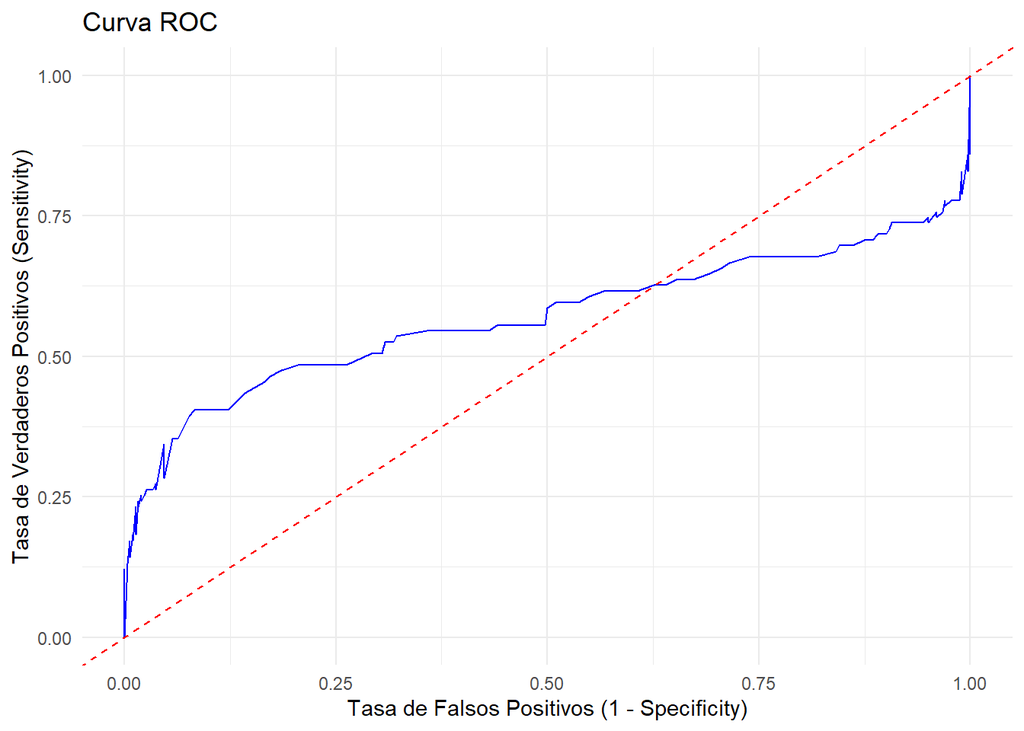

```r
roc_data <- data.frame(

  tpr = roc_obj$sensitivities,

  fpr = roc_obj$specificities

)


ggplot(roc_data, aes(x = 1 - fpr, y = tpr)) +

  geom_line(color = "blue") +

  geom_abline(linetype = "dashed", color = "red") +

  labs(title = "Curva ROC",

       x = "Tasa de Falsos Positivos (1 - Specificity)",

       y = "Tasa de Verdaderos Positivos (Sensitivity)") +

  theme_minimal()
```

Análisis de Resultados de la Regresión Logística y Comparación con QDA

Metodología

Se utilizó la regresión logística para clasificar la variedad de vino (blanco o tinto) utilizando un conjunto de datos de vinos. Para evaluar el rendimiento del modelo, los datos fueron divididos en un conjunto de entrenamiento (80%) y un conjunto de prueba (20%). Las variables predictoras fueron escaladas para asegurar que todas tuvieran la misma escala.

Resultados del Modelo de Regresión Logística El modelo de regresión logística fue ajustado utilizando todas las variables predictoras. Sin embargo, el resumen del modelo mostró que ninguna de las variables tenía un efecto significativo en la predicción de la variedad de vino, como se refleja en los p-valores extremadamente altos (1) para todas las variables.

Interpretación de los Resultados Los resultados de la regresión logística indican que el modelo tiene una alta sensibilidad (100%), clasificando correctamente a todos los vinos blancos. Sin embargo, falla en clasificar correctamente los vinos tintos.

[output not shown]